# Statistical Learning Assignment 1

Tarun Sudhams

22nd October 2018

## Question 1

*In this exercise you will create some simulated data and will fit simple linear regression models to it. Make sure to use set.seed(Your UID) prior to starting part (a) to ensure consistent results.*

*(a) Using the rnorm() function, create a vector, x, containing 100 observations drawn from a N(0,1) distribution. This represents a feature, X.*

```r
set.seed(3876)
x=rnorm(100, mean = 0, sd = 1)
```

*(b) Using the rnorm() function, create a vector, eps, containing 100 observations drawn from a N(0, 0.25) distribution i.e. a normal distribution with mean zero and variance 0.25.*

```r
eps = rnorm(100,mean=0,sd = 0.25)
```

*(c) Using x and eps, generate a vector y according to the model Y = -1+0.5X+ε.*

```r
y = -1+0.5*x + eps
length(y)
```

```
[1] 100
```

The length of Y is 100 and value of β^o is -1 and β^1 is 0.5.  
*(d) Create a scatterplot displaying the relationship between x and y. Comment on what you observe.*

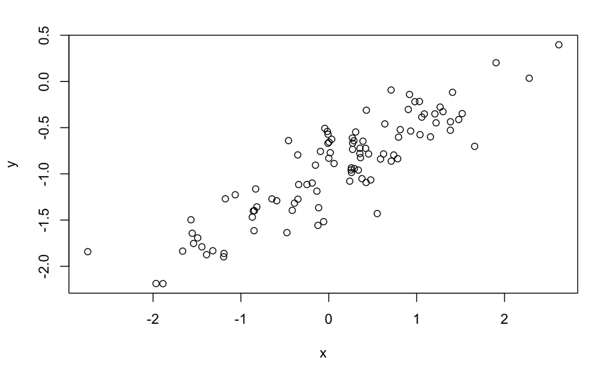

```r
plot(y~x)
```

The graph ploted above shows a linear relationship between Y and X.  
*(e) Fit a least squares linear model to predict y using x. Comment on the model obtained. How do βˆ0 and ?βˆ1 compare to β^o and β^1 ?*

```r
lm.fit = lm(y~x)
summary(lm.fit)
```

```
Call:
lm(formula = y ~ x)

Residuals:
     Min       1Q   Median       3Q      Max
-0.72668 -0.15521 -0.01708  0.19065  0.55342

Coefficients:
            Estimate Std. Error t value Pr(>|t|)
(Intercept) -0.97065    0.02542  -38.18   <2e-16 ***
x            0.48541    0.02590   18.74   <2e-16 ***
---
Signif. codes:  0 '***' 0.001 '**' 0.01 '*' 0.05 '.' 0.1 ' ' 1

Residual standard error: 0.2528 on 98 degrees of freedom
Multiple R-squared:  0.7819,    Adjusted R-squared:  0.7797
F-statistic: 351.3 on 1 and 98 DF,  p-value: < 2.2e-16
```

The linear regression fits very closely to the true value of the coefficients it was constructed from. The model has a large F-Statistic value and with a near zero p-value.  
*(f) Display the least squares line on the scatterplot obtained in (d). Draw the population regression line on the plot, in a different color. Use the legend() command to create an appropriate legend.*

```r
plot(x,y)
abline(lm.fit,lwd=3,col=2)
```

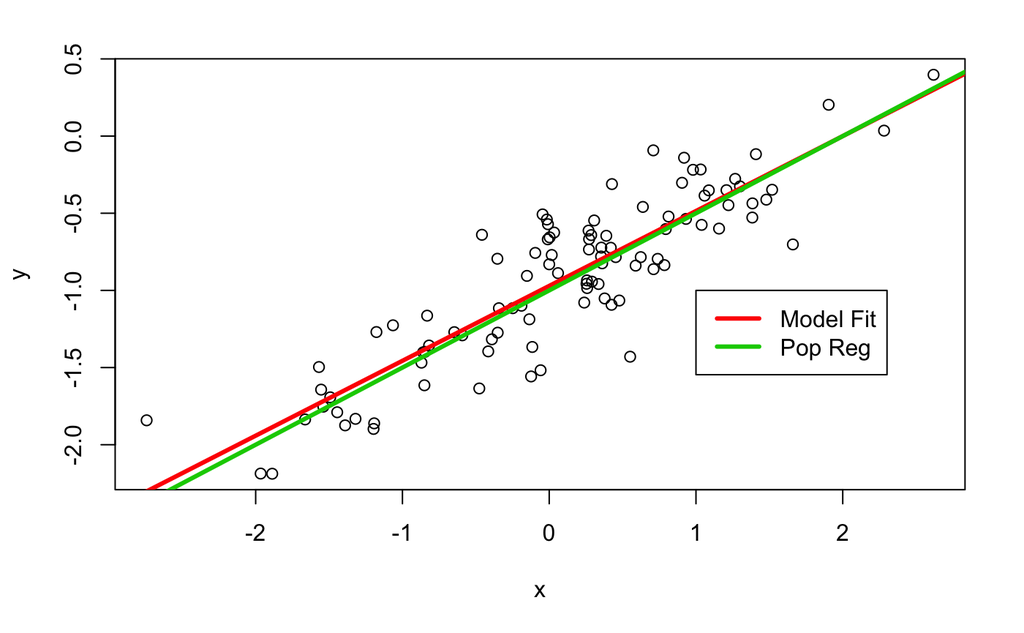

```r
abline(-1,0.5,lwd=3,col=3)
legend(-1, legend = c("Model Fit", "Pop Reg"), col=2:3,lwd=3)
```

*(g) Now fit a polynomial regression model that predicts y using x and x 2 . Is there evidence that the quadratic term improves the model fit? Explain your answer.*

```r
lm.fit_sq = lm(y~x + I(x^2))
summary(lm.fit_sq)
```

```
Call:
lm(formula = y ~ x + I(x^2))

Residuals:
     Min       1Q   Median       3Q      Max
-0.72806 -0.15612 -0.01772  0.18870  0.55172

Coefficients:
             Estimate Std. Error t value Pr(>|t|)
(Intercept) -0.968547   0.031411 -30.835   <2e-16 ***
x            0.485291   0.026048  18.631   <2e-16 ***
I(x^2)      -0.002171   0.018842  -0.115    0.908
---
Signif. codes:  0 '***' 0.001 '**' 0.01 '*' 0.05 '.' 0.1 ' ' 1

Residual standard error: 0.2541 on 97 degrees of freedom
Multiple R-squared:  0.7819,    Adjusted R-squared:  0.7774
F-statistic: 173.9 on 2 and 97 DF,  p-value: < 2.2e-16
```

*(h) Repeat (a)–(f) after modifying the data generation process in such a way that there is less noise in the data. The model (1) should remain the same. You can do this by decreasing the variance of the normal distribution used to generate the error term ε in (b). Describe your results.*

```r
set.seed(3876)
eps1 = rnorm(100, 0, 0.125)
x1 = rnorm(100)
y1 = -1 + .5*x1 + eps1
plot(x1,y1)
lm.fit1 = lm(y1~x1)
summary(lm.fit1)
```

```
Call:
lm(formula = y1 ~ x1)

Residuals:
     Min       1Q   Median       3Q      Max
-0.34198 -0.06718  0.01616  0.07991  0.31600

Coefficients:
            Estimate Std. Error t value Pr(>|t|)
(Intercept) -0.98624    0.01238  -79.65   <2e-16 ***
x1           0.49308    0.01227   40.17   <2e-16 ***
---
Signif. codes:  0 '***' 0.001 '**' 0.01 '*' 0.05 '.' 0.1 ' ' 1

Residual standard error: 0.1231 on 98 degrees of freedom
Multiple R-squared:  0.9428,    Adjusted R-squared:  0.9422
F-statistic:  1614 on 1 and 98 DF,  p-value: < 2.2e-16
```

```r
abline(lm.fit1, lwd=3,col=2)
```

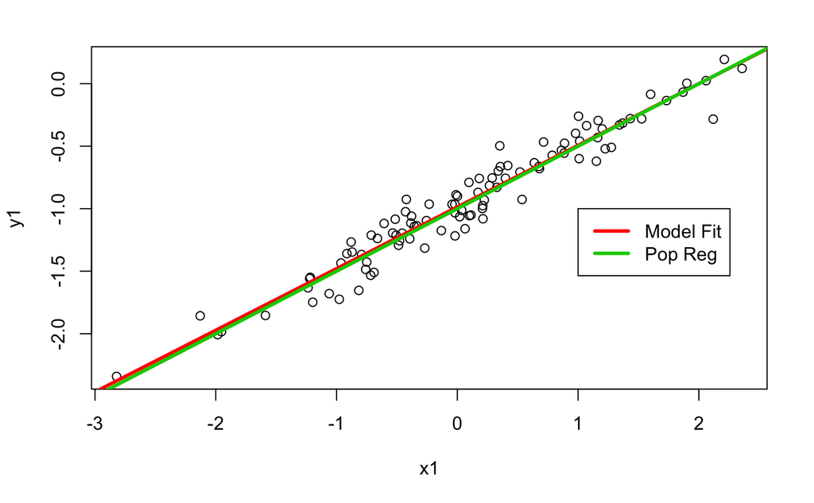

```r
abline(-1, 0.5, lwd=3,col=3)
legend(-1, legend = c("Model Fit", "Pop Reg"), col=2:3, lwd=3)
```

*(i) Repeat (a)–(f) after modifying the data generation process in such a way that there is more noise in the data. The model (1) should remain the same. You can do this by increasing the variance of the normal distribution used to generate the error term ε in (b). Describe your results.*

```r
set.seed(3876)
eps2 = rnorm(100,0,0.5)
x2 = rnorm(100)
y2 = -1 + 0.5*x2 + eps2
plot(x2,y2)
lm.fit2 = lm(y2~x2)
summary(lm.fit2)
```

```
Call:
lm(formula = y2 ~ x2)

Residuals:
     Min       1Q   Median       3Q      Max
-1.36790 -0.26871  0.06464  0.31962  1.26401

Coefficients:
            Estimate Std. Error t value Pr(>|t|)
(Intercept) -0.94496    0.04953 -19.078  < 2e-16 ***
x2           0.47234    0.04909   9.621 8.04e-16 ***
---
Signif. codes:  0 '***' 0.001 '**' 0.01 '*' 0.05 '.' 0.1 ' ' 1

Residual standard error: 0.4923 on 98 degrees of freedom
Multiple R-squared:  0.4857,    Adjusted R-squared:  0.4805
F-statistic: 92.57 on 1 and 98 DF,  p-value: 8.043e-16
```

```r
abline(lm.fit2, lwd = 3, col = 2)
```

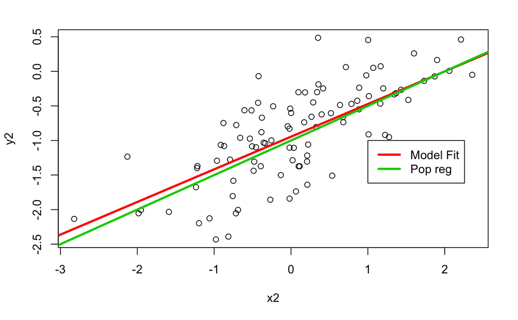

```r
abline(-1, 0.5, lwd = 3, col = 3)
legend(-1, legend = c("Model Fit", "Pop reg"), col=2:3, lwd = 3)
```

```r
confint(lm.fit)
```

```
                 2.5 %     97.5 %
(Intercept) -1.0211076 -0.9201974
x            0.4340156  0.5367998
```

```r
confint(lm.fit1)
```

```
                2.5 %     97.5 %
(Intercept) -1.010814 -0.9616677
x1           0.468728  0.5174405
```

```r
confint(lm.fit2)
```

```
                2.5 %     97.5 %
(Intercept) -1.043256 -0.8466707
x2           0.374912  0.5697622
```

Seems like all the confidence intervals are approximately around the 0.5 mark. fit1’s interval is observed to be slightly narrow than fit’s interval and fit2’s interval is wider than fit’s interval.

## Question 2

*In this problem, you will develop a model to predict whether a given car gets high or low gas mileage based on the Auto data set.*

*(a) Create a binary variable, mpg01, that contains a 1 if mpg contains a value above its median, and a 0 if mpg contains a value below its median. You can compute the median using the median() function. Note you may find it helpful to use the data.frame() function to create a single data set containing both mpg01 and the other Auto variables.*

```r
library(ISLR)
summary(Weekly)
```

```
      Year           Lag1               Lag2               Lag3               Lag4               Lag5              Volume            Today          Direction
 Min.   :1990   Min.   :-18.1950   Min.   :-18.1950   Min.   :-18.1950   Min.   :-18.1950   Min.   :-18.1950   Min.   :0.08747   Min.   :-18.1950   Down:484
 1st Qu.:1995   1st Qu.: -1.1540   1st Qu.: -1.1540   1st Qu.: -1.1580   1st Qu.: -1.1580   1st Qu.: -1.1660   1st Qu.:0.33202   1st Qu.: -1.1540   Up  :605
 Median :2000   Median :  0.2410   Median :  0.2410   Median :  0.2410   Median :  0.2380   Median :  0.2340   Median :1.00268   Median :  0.2410
 Mean   :2000   Mean   :  0.1506   Mean   :  0.1511   Mean   :  0.1472   Mean   :  0.1458   Mean   :  0.1399   Mean   :1.57462   Mean   :  0.1499
 3rd Qu.:2005   3rd Qu.:  1.4050   3rd Qu.:  1.4090   3rd Qu.:  1.4090   3rd Qu.:  1.4090   3rd Qu.:  1.4050   3rd Qu.:2.05373   3rd Qu.:  1.4050
 Max.   :2010   Max.   : 12.0260   Max.   : 12.0260   Max.   : 12.0260   Max.   : 12.0260   Max.   : 12.0260   Max.   :9.32821   Max.   : 12.0260
```

```r
data("Auto")
mpg01 <- rep(0,length(Auto$mpg))
mpg01[Auto$mpg > median(Auto$mpg)] <- 1
Auto <- data.frame(Auto, mpg01)
summary(Auto)
```

```
      mpg          cylinders      displacement     horsepower        weight      acceleration        year           origin                      name         mpg01
 Min.   : 9.00   Min.   :3.000   Min.   : 68.0   Min.   : 46.0   Min.   :1613   Min.   : 8.00   Min.   :70.00   Min.   :1.000   amc matador       :  5   Min.   :0.0
 1st Qu.:17.00   1st Qu.:4.000   1st Qu.:105.0   1st Qu.: 75.0   1st Qu.:2225   1st Qu.:13.78   1st Qu.:73.00   1st Qu.:1.000   ford pinto        :  5   1st Qu.:0.0
 Median :22.75   Median :4.000   Median :151.0   Median : 93.5   Median :2804   Median :15.50   Median :76.00   Median :1.000   toyota corolla    :  5   Median :0.5
 Mean   :23.45   Mean   :5.472   Mean   :194.4   Mean   :104.5   Mean   :2978   Mean   :15.54   Mean   :75.98   Mean   :1.577   amc gremlin       :  4   Mean   :0.5
 3rd Qu.:29.00   3rd Qu.:8.000   3rd Qu.:275.8   3rd Qu.:126.0   3rd Qu.:3615   3rd Qu.:17.02   3rd Qu.:79.00   3rd Qu.:2.000   amc hornet        :  4   3rd Qu.:1.0
 Max.   :46.60   Max.   :8.000   Max.   :455.0   Max.   :230.0   Max.   :5140   Max.   :24.80   Max.   :82.00   Max.   :3.000   chevrolet chevette:  4   Max.   :1.0
                                                                                                                                (Other)           :365
```

*(b) Explore the data graphically in order to investigate the association between mpg01 and the other features. Which of the other features seem most likely to be useful in predicting mpg01? Scatterplots and boxplots may be useful tools to answer this question. Describe your findings.*

```r
cor(Auto[,-9])
```

```
                    mpg  cylinders displacement horsepower     weight acceleration       year     origin      mpg01
mpg           1.0000000 -0.7776175   -0.8051269 -0.7784268 -0.8322442    0.4233285  0.5805410  0.5652088  0.8369392
cylinders    -0.7776175  1.0000000    0.9508233  0.8429834  0.8975273   -0.5046834 -0.3456474 -0.5689316 -0.7591939
displacement -0.8051269  0.9508233    1.0000000  0.8972570  0.9329944   -0.5438005 -0.3698552 -0.6145351 -0.7534766
horsepower   -0.7784268  0.8429834    0.8972570  1.0000000  0.8645377   -0.6891955 -0.4163615 -0.4551715 -0.6670526
weight       -0.8322442  0.8975273    0.9329944  0.8645377  1.0000000   -0.4168392 -0.3091199 -0.5850054 -0.7577566
acceleration  0.4233285 -0.5046834   -0.5438005 -0.6891955 -0.4168392    1.0000000  0.2903161  0.2127458  0.3468215
year          0.5805410 -0.3456474   -0.3698552 -0.4163615 -0.3091199    0.2903161  1.0000000  0.1815277  0.4299042
origin        0.5652088 -0.5689316   -0.6145351 -0.4551715 -0.5850054    0.2127458  0.1815277  1.0000000  0.5136984
mpg01         0.8369392 -0.7591939   -0.7534766 -0.6670526 -0.7577566    0.3468215  0.4299042  0.5136984  1.0000000
```

### Corrplot

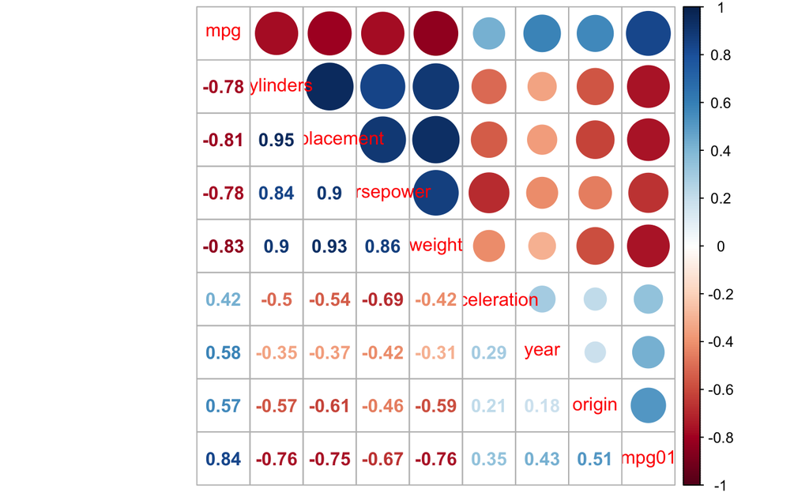

```r
library(corrplot)
corrplot::corrplot.mixed(cor(Auto[,-9]), upper="circle")
```

### Scatterplot Matrix

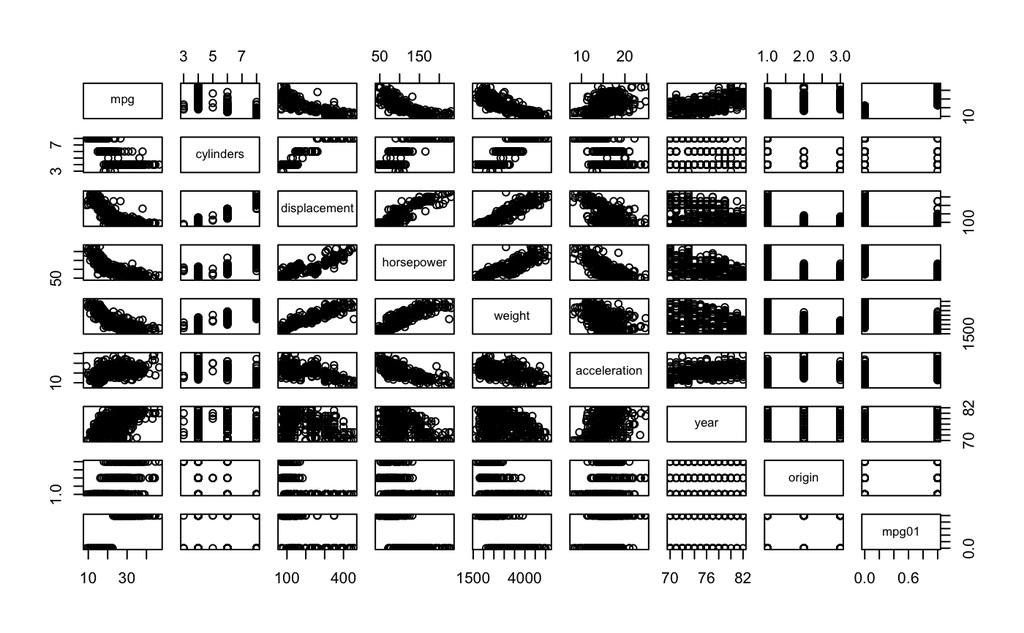

```r
pairs(Auto[, -9])
```

### Boxplots

```r
par(mfrow=c(2,3))
boxplot(displacement ~ mpg01, data = Auto, main = "Displacement vs. mpg01")
boxplot(cylinders ~ mpg01, data = Auto, main = "Cylinders vs. mpg01")
```

```r
boxplot(weight ~ mpg01, data = Auto, main = "Weight vs. mpg01")
boxplot(horsepower ~ mpg01, data = Auto, main = "Horsepower vs. mpg01")
```

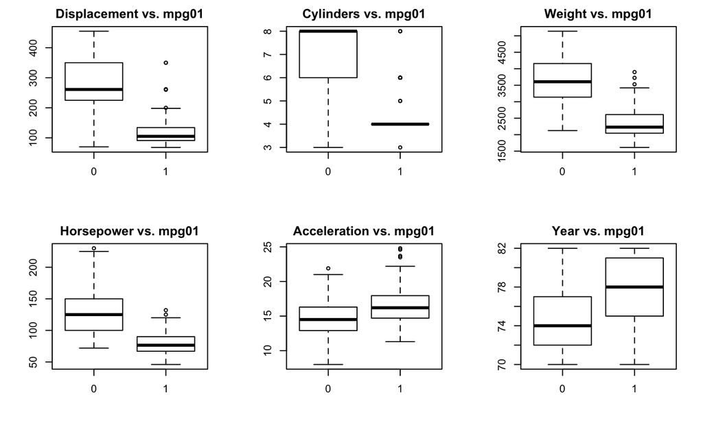

```r
boxplot(acceleration ~ mpg01, data = Auto, main = "Acceleration vs. mpg01")
boxplot(year ~ mpg01, data = Auto, main = "Year vs. mpg01")
```

There exists a clear anti-correlation between “mpg01” and cyclinders“,”displacement“,”horsepower" and “weight”.

*(c) Split the data into a training set and a test set.*

```r
set.seed(123)
train <- sample(1:dim(Auto)[1], dim(Auto)[1]*.7, rep=FALSE)
test <- train
training_data = Auto[train, ]
testing_data = Auto[test, ]
mpg01.test <- mpg01[test]
```

*(f) Perform logistic regression on the training data in order to predict mpg01 using the variables that seemed most associated with mpg01 in (b). What is the test error of the model obtained?*

```r
glm.fit = glm(mpg01 ~ cylinders + weight + displacement + horsepower, data = Auto,
    family = binomial, subset = train)
glm.probs = predict(glm.fit, testing_data, type = "response")
glm.pred = rep(0, length(glm.probs))
glm.pred[glm.probs > 0.5] = 1
mean(glm.pred != mpg01.test)
```

```
[1] 0.09489051
```

## Question 3

*We continue to consider the use of a logistic regression model to predict the probability of default using income and balance on the Default data set. In particular, we will now compute estimates for the standard errors of the income and balance logistic regression coefficients in two different ways: (1) using the bootstrap, and (2) using the standard formula for computing the standard errors in the glm() function. Do not forget to set a random seed before beginning your analysis.*

*(a) Using the summary() and glm() functions, determine the estimated standard errors for the coefficients associated with income and balance in a multiple logistic regression model that uses both predictors.*

```r
set.seed(3876)
attach(Default)
glm.fit = glm(default ~ income + balance, data = Default, family = binomial)
summary(glm.fit)
```

```
Call:
glm(formula = default ~ income + balance, family = binomial,
    data = Default)

Deviance Residuals:
    Min       1Q   Median       3Q      Max
-2.4725  -0.1444  -0.0574  -0.0211   3.7245

Coefficients:
              Estimate Std. Error z value Pr(>|z|)
(Intercept) -1.154e+01  4.348e-01 -26.545  < 2e-16 ***
income       2.081e-05  4.985e-06   4.174 2.99e-05 ***
balance      5.647e-03  2.274e-04  24.836  < 2e-16 ***
---
Signif. codes:  0 '***' 0.001 '**' 0.01 '*' 0.05 '.' 0.1 ' ' 1

(Dispersion parameter for binomial family taken to be 1)

    Null deviance: 2920.6  on 9999  degrees of freedom
Residual deviance: 1579.0  on 9997  degrees of freedom
AIC: 1585

Number of Fisher Scoring iterations: 8
```

The glm() estimates of standard errors for the coefficients β0, β1 and β2 are 0.434756, 4.9841572 x 10^{-6} and 2.2737314 x 10^{-4}

*(b) Write a function, boot.fn(), that takes as input the Default data set as well as an index of the observations, and that outputs the coefficient estimates for income and balance in the multiple logistic regression model.*

```r
boot.fn <- function(data,index)
{
  fit <-glm(default ~ income + balance, data = data, family = "binomial", subset = index)
  return (coef(fit))
}
```

*(c) Write a function, boot.fn(), that takes as input the Default data set as well as an index of the observations, and that outputs the coefficient estimates for income and balance in the multiple logistic regression model.*

```r
library(boot)
boot(Default, boot.fn, 1000)
```

```
ORDINARY NONPARAMETRIC BOOTSTRAP


Call:
boot(data = Default, statistic = boot.fn, R = 1000)


Bootstrap Statistics :
         original        bias     std. error
t1* -1.154047e+01 -1.451662e-02 4.281430e-01
t2*  2.080898e-05  2.160095e-08 4.690553e-06
t3*  5.647103e-03  7.653440e-06 2.288706e-04
```

*(d) Comment on the estimated standard errors obtained using the glm() function and using your bootstrap function.*

The glm() estimates and bootstrap estimates of the standard errors are very similar to each other.

## Question 4

*We will now consider the Boston housing data set, from the MASS library.*

*(a) Based on this data set, provide an estimate for the population mean of medv. Call this estimate μˆ.*

```r
library(MASS)
summary(Boston)
```

```
      crim                zn             indus            chas              nox               rm             age              dis              rad              tax
 Min.   : 0.00632   Min.   :  0.00   Min.   : 0.46   Min.   :0.00000   Min.   :0.3850   Min.   :3.561   Min.   :  2.90   Min.   : 1.130   Min.   : 1.000   Min.   :187.0
 1st Qu.: 0.08204   1st Qu.:  0.00   1st Qu.: 5.19   1st Qu.:0.00000   1st Qu.:0.4490   1st Qu.:5.886   1st Qu.: 45.02   1st Qu.: 2.100   1st Qu.: 4.000   1st Qu.:279.0
 Median : 0.25651   Median :  0.00   Median : 9.69   Median :0.00000   Median :0.5380   Median :6.208   Median : 77.50   Median : 3.207   Median : 5.000   Median :330.0
 Mean   : 3.61352   Mean   : 11.36   Mean   :11.14   Mean   :0.06917   Mean   :0.5547   Mean   :6.285   Mean   : 68.57   Mean   : 3.795   Mean   : 9.549   Mean   :408.2
 3rd Qu.: 3.67708   3rd Qu.: 12.50   3rd Qu.:18.10   3rd Qu.:0.00000   3rd Qu.:0.6240   3rd Qu.:6.623   3rd Qu.: 94.08   3rd Qu.: 5.188   3rd Qu.:24.000   3rd Qu.:666.0
 Max.   :88.97620   Max.   :100.00   Max.   :27.74   Max.   :1.00000   Max.   :0.8710   Max.   :8.780   Max.   :100.00   Max.   :12.127   Max.   :24.000   Max.   :711.0
    ptratio          black            lstat            medv
 Min.   :12.60   Min.   :  0.32   Min.   : 1.73   Min.   : 5.00
 1st Qu.:17.40   1st Qu.:375.38   1st Qu.: 6.95   1st Qu.:17.02
 Median :19.05   Median :391.44   Median :11.36   Median :21.20
 Mean   :18.46   Mean   :356.67   Mean   :12.65   Mean   :22.53
 3rd Qu.:20.20   3rd Qu.:396.23   3rd Qu.:16.95   3rd Qu.:25.00
 Max.   :22.00   Max.   :396.90   Max.   :37.97   Max.   :50.00
```

```r
set.seed(3876)
attach(Boston)
mu_hat <- mean(medv)
mu_hat
```

```
[1] 22.53281
```

*(b) Provide an estimate of the standard error of μˆ. Interpret this result.*

```r
x.hat <- sd(medv) / sqrt(dim(Boston)[1])
x.hat
```

```
[1] 0.4088611
```

*(c) Now estimate the standard error of μˆ using the bootstrap. How does this compare to your answer from (b)?*

```r
boot.fn = function(data, index) return(mean(data[index]))
library(boot)
bstrap = boot(medv, boot.fn, 1000)
bstrap
```

```
ORDINARY NONPARAMETRIC BOOTSTRAP


Call:
boot(data = medv, statistic = boot.fn, R = 1000)


Bootstrap Statistics :
    original      bias    std. error
t1* 22.53281 0.007578063   0.4114338
```

*(d) Based on your bootstrap estimate from (c), provide a 95 % confidence interval for the mean of medv. Compare it to the results obtained using t.test(Boston$medv).*

```r
t.test(medv)
```

```
    One Sample t-test

data:  medv
t = 55.111, df = 505, p-value < 2.2e-16
alternative hypothesis: true mean is not equal to 0
95 percent confidence interval:
 21.72953 23.33608
sample estimates:
mean of x
 22.53281
```

```r
ConfidenceInterval.mu.hat <- c(22.53 - 2 * 0.4114, 22.53 + 2 * 0.4114)
ConfidenceInterval.mu.hat
```

```
[1] 21.7072 23.3528
```

The confidence interval of bootstrap is very close to the one returned test function.

*(e) Based on this dataset, provide an estimate, μˆ med , for the median value of medv in the population.*

```r
med_hat <- median(medv)
med_hat
```

```
[1] 21.2
```

*(f) We now would like to estimate the standard error of μˆ med . Unfortunately, there is no simple formula for computing the standard error of the median. Instead, estimate the standard error of the median using the bootstrap. Comment on your findings.*

```r
boot.fn = function(data,index) return (median(data[index]))
boot(medv, boot.fn, 1000)
```

```
ORDINARY NONPARAMETRIC BOOTSTRAP


Call:
boot(data = medv, statistic = boot.fn, R = 1000)


Bootstrap Statistics :
    original  bias    std. error
t1*     21.2 0.01195   0.3808145
```

*(g) Based on this data set, provide an estimate for the tenth percentile of medv in Boston suburbs. Call this quantity μˆ 0.1 .*

```r
percentile_hat <- quantile(medv, c(0.1))
percentile_hat
```

```
  10%
12.75
```

*(h) Use the bootstrap to estimate the standard error of μ̂ 0.1 Comment on your findings.*

```r
boot.fn = function(data, index) return(quantile(data[index], c(0.1)))
boot(medv, boot.fn, 1000)
```

```
ORDINARY NONPARAMETRIC BOOTSTRAP


Call:
boot(data = medv, statistic = boot.fn, R = 1000)


Bootstrap Statistics :
    original  bias    std. error
t1*    12.75 -0.0113   0.5168844
```

The estimated 10th percentile value of 12.75 is the same to the value obtained in (g) with a standard error of 0.5168 which is quite small when compared to the percentile value.